# task1 - Цзян Чжэнхуа

2024-02-21

## task1(Вариант3)

### 1.Построить аддитивную и мультипликативную оценку сезонной компоненты для процесса доли (процента) каждодневного изменения числа заболевших, начиная с 1 сентября 2022 года по 31 декабря 2022.

Сначала я обработал данные,и вычислить процесса доли (процента) каждодневного изменения числа заболевших, начиная с 1 сентября 2022 года по 31 декабря 2022.

```r
library(COVID19)
x <- covid19("China",level =1,start='2022-09-01',end = '2022-12-31')
```

[output not shown]

```r
x <- x[,2:7]
head(x)
```

```
##         date confirmed deaths recovered tests   vaccines
## 1 2022-09-01   6439671  24927        NA  <NA> 3432984000
## 2 2022-09-02   6477468  24976        NA  <NA> 3433182000
## 3 2022-09-03   6514732  25019        NA  <NA> 3433328000
## 4 2022-09-04   6551088  25058        NA  <NA> 3433450000
## 5 2022-09-05   6588871  25088        NA  <NA> 3433615000
## 6 2022-09-06   6616059  25130        NA  <NA> 3433788000
```

```r
# Calculate the number of new confirmed cases per day
confirmed <- diff(x$confirmed)
n <-length(confirmed)
# Calculate the rate of increase in the number of confirmed cases per day (negative values indicate a decrease).
rate.conf <- confirmed[2:n]/confirmed[1:(n-1)]-1
rate.conf
```

```
##   [1] -0.014101648 -0.024366681  0.039250743 -0.280417119  0.457518023
##   [6]  0.124662478 -0.137994480 -0.030247026  0.032103073 -0.098176900
##  [11] -0.198581151  0.774415257  0.056336314 -0.076542072 -0.084092138
##  [16] -0.054225208 -0.002519919 -0.274210235  0.535238348  0.052103127
##  [21] -0.091636737 -0.059647537 -0.043008169  0.014913382 -0.254799129
##  [26]  0.563006241  0.062123014 -0.074366614 -0.030935407 -0.012372375
##  [31]  0.006568404 -0.218280486  0.460814687  0.109241222 -0.147556075
##  [36]  0.092872570 -0.122282609  0.005650696 -0.265726588  0.265341426
##  [41]  0.261649327  0.016767985 -0.094288501 -0.097702525 -0.037022302
##  [46] -0.293564084  0.513743583 -0.003434213 -0.111608874 -0.055251164
##  [51] -0.030896354 -0.013689925 -0.240737758  0.452282451  0.031700429
##  [56] -0.108061547 -0.026590819 -0.064039141 -0.019689841 -0.267685745
##  [61]  0.463389968 -0.111043538  0.099912930 -0.175793729 -0.047473673
##  [66] -0.053440887 -0.276317291  0.451266954  0.006882562 -0.094941718
##  [71] -0.071987916 -0.034823953 -0.015133360 -0.098684211  0.092940706
##  [76]  0.242944056 -0.091601649 -0.100838634 -0.066909976 -0.006132599
##  [81] -0.218491886  0.427354678  0.056622675 -0.112329445 -0.080152317
##  [86] -0.041902262  0.007587733 -0.147264930  0.451122286  0.032414842
##  [91] -0.082770478 -0.082965145 -0.042875219  0.011847257 -0.104070352
##  [96]  0.314319367  0.052319379 -0.084188329 19.523004030  0.178116862
## [101]  0.369711532  0.198167120  0.149631404  0.184187919  0.467102755
## [106]  0.285343368  0.353720915  0.306550044  0.254152464  0.157233345
## [111]  0.089637262  0.082583849 -0.091622278 -0.103975615 -0.159014749
## [116] -0.064130360 -0.023688392 -0.188993135 -0.170983695 -0.170677002
```

Затем построить аддитивную и мультипликативную оценку сезонной компоненты. Поскольку неделя состоит из 7 дней, установите frequency = 7.

```r
# Creating Time Series Objects
rate_sequencest <- ts(rate.conf, frequency = 7)
```

### аддитивная модель

```r
# Seasonal decomposition using additive modeling
addseason <- decompose(rate_sequencest, type = "additive")
```

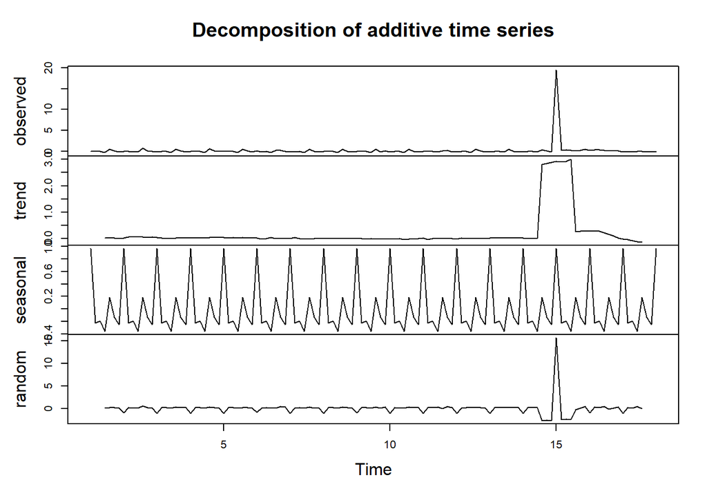

```r
plot(addseason)
```

### мультипликативная модель

```r
# Seasonal decomposition using a multiplicative model
multseason <- decompose(rate_sequencest, type = "multiplicative")
```

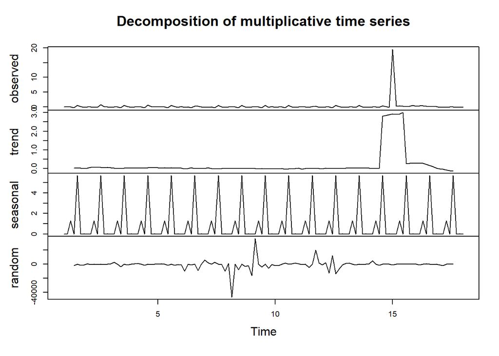

```r
plot(multseason)
```

### 2.Построить графики недельной сезонной компонент с привязкой ко дням недели.

### аддитивная модель

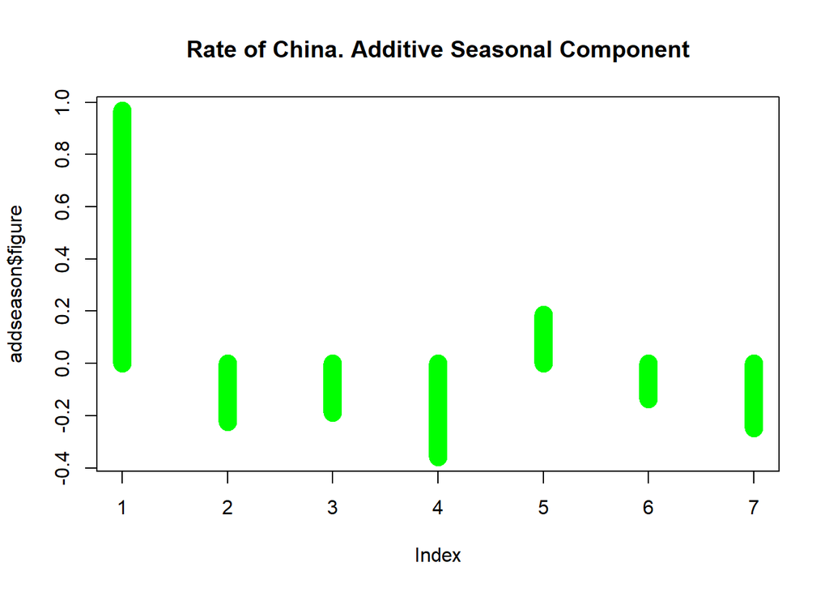

```r
# Plotting the seasonal components of time series
plot(addseason$figure,type = "h",main = 'Rate of China. Additive Seasonal Component',col = 'green',lwd = 15 )
```

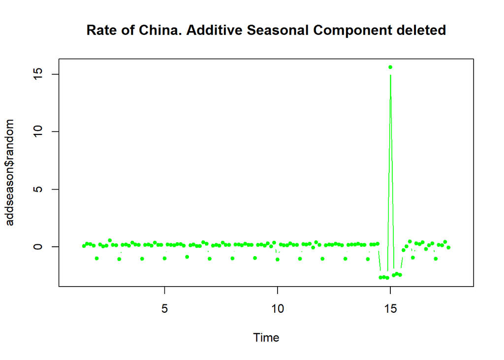

```r
# Plotting the residual components of a time series
plot(addseason$random,type = 'b',pch = 20,main = 'Rate of China. Additive Seasonal Component deleted',col = 'green',lwd = 1 )
```

### мультипликативная модель

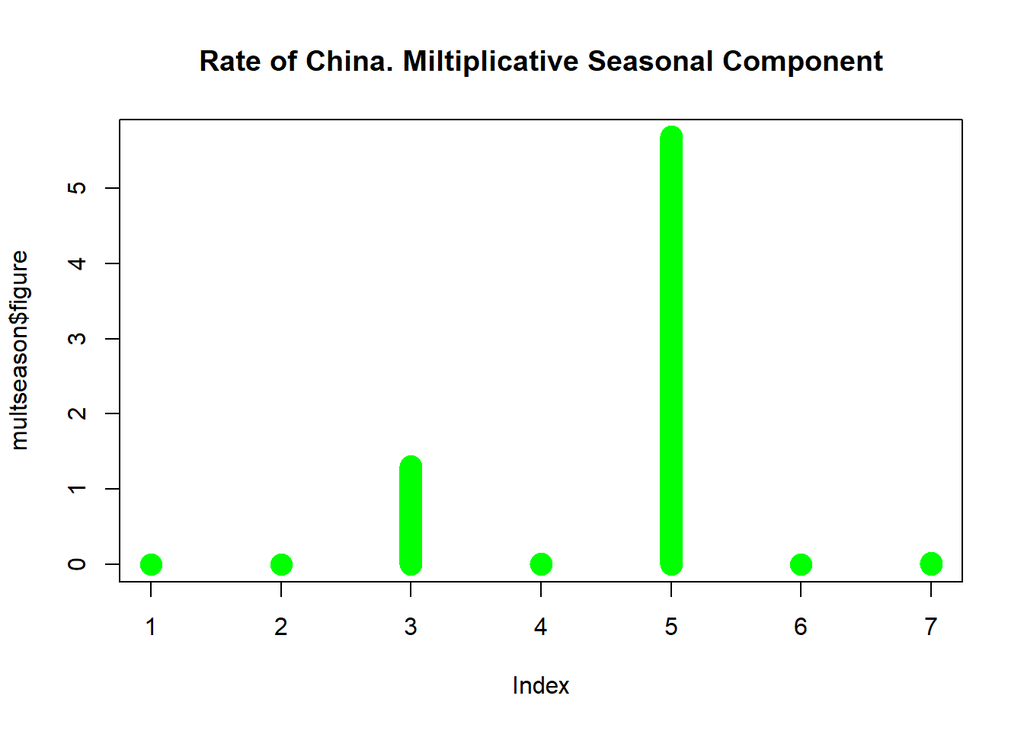

```r
# Plotting the seasonal components of time series
plot(multseason$figure,type = "h",main = 'Rate of China. Miltiplicative Seasonal Component',col = 'green',lwd = 15 )
```

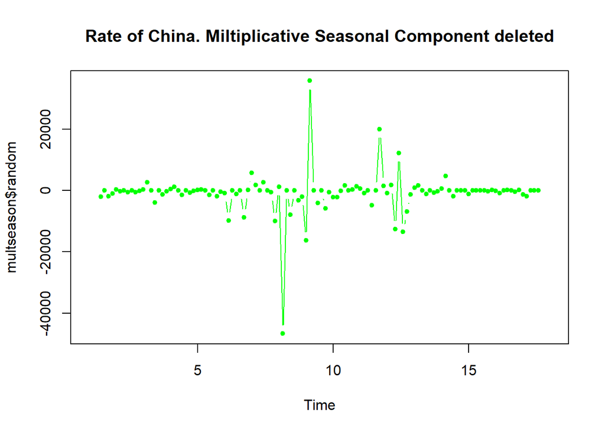

```r
# Plotting the residual components of a time series
plot(multseason$random,type = 'b',pch = 20,main = 'Rate of China. Miltiplicative Seasonal Component deleted',col = 'green',lwd = 1 )
```

### 3.В какой день недели изменение доли числа заболевших максимально и минимально

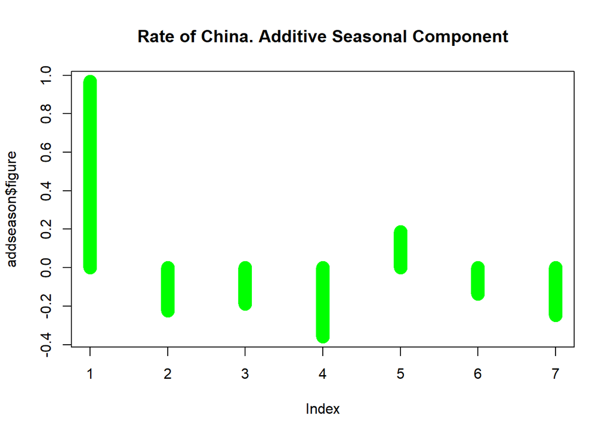

```r
# Plotting the seasonal components of time series
plot(addseason$figure,type = "h",main = 'Rate of China. Additive Seasonal Component',col = 'green',lwd = 15 )
```

### 4.Оценить показатель Херста к ряду для лагов 7,30,60,90 дней. Персистентный или антиперсистентный ряд.

Определение функции, используемой для вычисления показателя Херста.

```r
getHurstExponent <- function(timeSeries, maxLag = 20) {
  # Generate range of hysteresis values
  lags <- 2:maxLag

  # Calculate the standard deviation of the lag difference
  tau <- sapply(lags, function(lag) {
    std.dev <- sd(timeSeries[(lag+1):length(timeSeries)] - timeSeries[1:(length(timeSeries)-lag)])
    return(std.dev)
  })

  reg <- lm(log(tau) ~ log(lags))

  # Returns the Hurst exponent, an estimate of the slope of the linear model
  return(coef(reg)[2])
}
```

Оценить показатель Херста к ряду для лагов 7,30,60,90 дней.

```r
lags <- c(7, 30, 60, 90)
# Iterate over the lagged values, calculate and print the Hurst exponent
for (lag in lags) {
  hurstExp <- getHurstExponent(rate_sequencest, lag)
  cat(sprintf("Hurst exponent with %d lags: %.4f\n", lag, hurstExp))
}
```

```
## Hurst exponent with 7 lags: 0.0192
## Hurst exponent with 30 lags: -0.0869
## Hurst exponent with 60 lags: -0.0589
## Hurst exponent with 90 lags: 0.0489
```

Согласно полученным результатам, значения экспоненты Харста все ниже 0,5, и ряд является антиперсистентным.

### 5.Проверить остатки после удаления сезонных компонент на стационарность. Выдать P-value соответствующего критерия и вывод о стационарности.

```r
library(tseries)
decomposed_rate <- decompose(rate_sequencest)

# Getting the residuals
residuals <- decomposed_rate$random
residuals <- na.omit(residuals)

# Checking the smoothness of residuals using the ADF test
adf_test_result <- adf.test(residuals, alternative = "stationary")
print(adf_test_result)
```

```
##
##  Augmented Dickey-Fuller Test
##
## data:  residuals
## Dickey-Fuller = -8.2611, Lag order = 4, p-value = 0.01
## alternative hypothesis: stationary
```

```r
# Determine whether the residual sequence is smooth or not based on p-value
if (adf_test_result$p.value < 0.05) {
  cat("The sequence of residuals is smooth，p-value:", adf_test_result$p.value, "\n")
} else {
  cat("The residual sequence is not smooth，p-value:", adf_test_result$p.value, "\n")
}
```

```
## The sequence of residuals is smooth，p-value: 0.01
```

### 6.Построить автокорреляционную функцию для остатков.

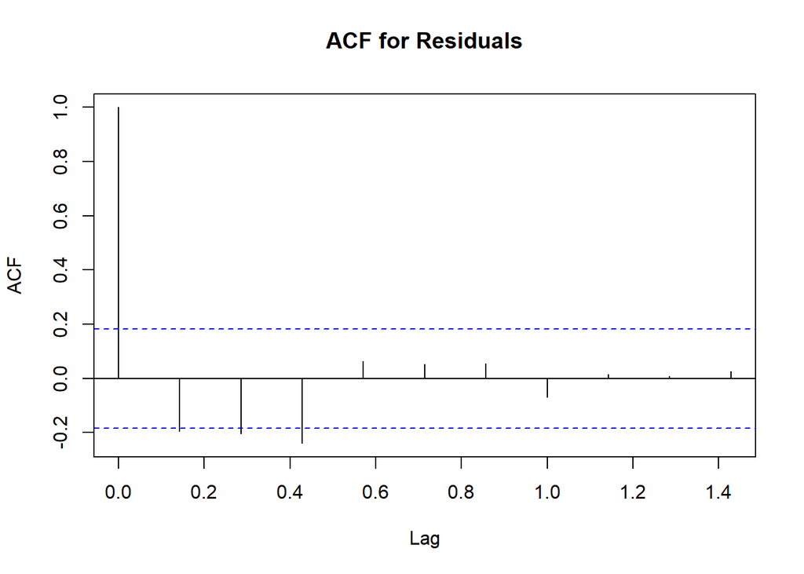

```r
library(stats)
# Plotting the autocorrelation of residuals using the acf() function
acf(residuals, main = "ACF for Residuals", lag.max = 10)
```

Таким образом, можно сделать вывод, что остаточный ряд является гладким, что согласуется с выводом, сделанным с помощью теста p-value.